# ML_III_unsupervised-learning

2026-02-04

```r
knitr::opts_chunk$set(echo = TRUE)
library(tidyverse)
library(tidymodels)
library(reportRmd)
```

```r
library(sjPlot)
library(plotly)
library(dplyr)
library(psych)
library(parallel)
library(finalfit)
library(gtsummary)
library(mlbench)
library(vip)
library(rsample)
library(tune)
library(recipes)
library(yardstick)
library(parsnip)
library(glmnet)
library(themis)
library(corrr)
library(performance)
library(utils)
library(see)
library(devtools)
library(tidyclust)
library(ClusterR)
library(klaR)
library(parsnip)
library(GGally)
library(ggplot2)
library(knitr)
```

```r
# Load Data

data <- read_csv("can_path_data.csv")
```

### Q-1: Dataset Exploration

```r
# Creating new dataset with 10 numeric variables plus ID

data <- data |> dplyr:: select(ID, SDC_AGE_CALC, PA_TOTAL_SHORT, PM_BMI_SR, SDC_EDU_LEVEL_AGE, PSE_ADULT_WRK_DURATION, PM_WAIST_HIP_RATIO_SR, SLE_TIME, NUT_VEG_QTY, NUT_FRUITS_QTY, ALC_CUR_FREQ)
```

```r
# Summary Statistics

rm_covsum(data=data,
covs=c('SDC_AGE_CALC','PA_TOTAL_SHORT', 'PM_BMI_SR', 'SDC_EDU_LEVEL_AGE', 'PSE_ADULT_WRK_DURATION', 'PM_WAIST_HIP_RATIO_SR', 'SLE_TIME', 'NUT_VEG_QTY', 'NUT_FRUITS_QTY', 'ALC_CUR_FREQ'))
```

|  | n=41187 |
| --- | --- |
| SDC AGE CALC |  |
| Mean (sd) | 51.5 (10.8) |
| Median (Min,Max) | 52 (30, 74) |
| PA TOTAL SHORT |  |
| Mean (sd) | 2574.1 (2656.2) |
| Median (Min,Max) | 1782 (0, 19278) |
| Missing | 6763 |
| PM BMI SR |  |
| Mean (sd) | 27.5 (6.2) |
| Median (Min,Max) | 26.6 (8.9, 69.4) |
| Missing | 11976 |
| SDC EDU LEVEL AGE |  |
| Mean (sd) | 25.4 (9.2) |
| Median (Min,Max) | 23 (-7, 73) |
| Missing | 2817 |
| PSE ADULT WRK DURATION |  |
| Mean (sd) | 6.6 (9.4) |
| Median (Min,Max) | 2 (0, 51) |
| Missing | 5731 |
| PM WAIST HIP RATIO SR |  |
| Mean (sd) | 0.9 (0.1) |
| Median (Min,Max) | 0.9 (0.3, 2.4) |
| Missing | 17734 |
| SLE TIME |  |
| Mean (sd) | 435.9 (75.1) |
| Median (Min,Max) | 430 (0, 1390) |
| Missing | 2792 |
| NUT VEG QTY |  |
| Mean (sd) | 2.7 (1.7) |
| Median (Min,Max) | 2 (0, 35) |
| Missing | 2549 |
| NUT FRUITS QTY |  |
| Mean (sd) | 2.1 (1.4) |
| Median (Min,Max) | 2 (0, 25) |
| Missing | 2426 |
| ALC CUR FREQ |  |
| Mean (sd) | 3.0 (3.3) |
| Median (Min,Max) | 3 (-7, 7) |
| Missing | 1683 |

```r
# Recoding- Age when completing education and alcohol consumption frequency and removing missing values


data <- data %>% mutate(SDC_EDU_LEVEL_AGE = if_else(SDC_EDU_LEVEL_AGE < 0, NA_real_, SDC_EDU_LEVEL_AGE))
data <- data %>% mutate(ALC_CUR_FREQ = if_else(ALC_CUR_FREQ < 0, NA_real_, ALC_CUR_FREQ))


# Drop NA
data <- drop_na(data)
```

```r
# Summary Statistics


rm_covsum(data=data,
covs=c('SDC_AGE_CALC','PA_TOTAL_SHORT', 'PM_BMI_SR', 'SDC_EDU_LEVEL_AGE', 'PSE_ADULT_WRK_DURATION', 'PM_WAIST_HIP_RATIO_SR', 'SLE_TIME', 'NUT_VEG_QTY', 'NUT_FRUITS_QTY', 'ALC_CUR_FREQ'))
```

|  | n=16081 |
| --- | --- |
| SDC AGE CALC |  |
| Mean (sd) | 51.9 (10.6) |
| Median (Min,Max) | 53 (30, 74) |
| PA TOTAL SHORT |  |
| Mean (sd) | 2712.5 (2678.7) |
| Median (Min,Max) | 1935 (0, 19278) |
| PM BMI SR |  |
| Mean (sd) | 27.4 (5.9) |
| Median (Min,Max) | 26.5 (8.9, 69.4) |
| SDC EDU LEVEL AGE |  |
| Mean (sd) | 25.2 (8.5) |
| Median (Min,Max) | 23 (1, 73) |
| PSE ADULT WRK DURATION |  |
| Mean (sd) | 6.7 (9.5) |
| Median (Min,Max) | 2 (0, 51) |
| PM WAIST HIP RATIO SR |  |
| Mean (sd) | 0.9 (0.1) |
| Median (Min,Max) | 0.9 (0.4, 2.4) |
| SLE TIME |  |
| Mean (sd) | 436.2 (71.4) |
| Median (Min,Max) | 431 (0, 1390) |
| NUT VEG QTY |  |
| Mean (sd) | 2.7 (1.6) |
| Median (Min,Max) | 2 (0, 30) |
| NUT FRUITS QTY |  |
| Mean (sd) | 2.1 (1.3) |
| Median (Min,Max) | 2 (0, 21) |
| ALC CUR FREQ |  |
| Mean (sd) | 3.7 (2.2) |
| Median (Min,Max) | 4 (0, 7) |

```
## Non-numeric variables removed from input: `ID`
## Correlation computed with
## • Method: 'pearson'
## • Missing treated using: 'pairwise.complete.obs'
```

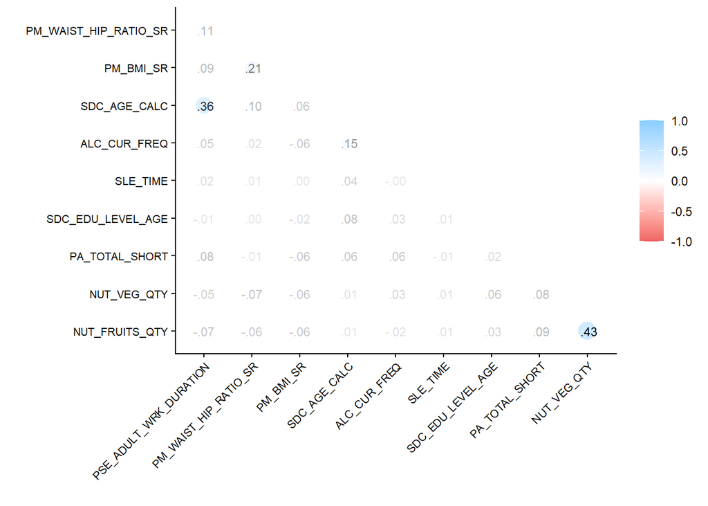

```r
# Correlations between variables

data |>
  correlate() |>
  rearrange() |>
  shave()  |>
  rplot(print_cor=TRUE) +
  theme(
    axis.text.x = element_text(angle = 45, hjust = 1, vjust = 1, size = 08),
    axis.text.y = element_text(size = 08)

    )
```

### Q-2: Baseline PCA Model

```r
# Recipe for PCA

pca_recipe <- recipe(~., data = data) |>
  update_role(ID, new_role = "id") |>
  step_scale(all_predictors()) |>
  step_center(all_predictors()) |>
  step_zv(all_predictors()) |>
  step_pca(all_predictors(), id = "pca_id")

pca_recipe
```

```
## ── Recipe ──────────────────────────────────────────────────────────────────────
```

```
## ── Inputs
```

```
## Number of variables by role
```

```
## predictor: 10
## id:         1
```

```
## ── Operations
```

```
## • Scaling for: all_predictors()
```

```
## • Centering for: all_predictors()
```

```
## • Zero variance filter on: all_predictors()
```

```
## • PCA extraction with: all_predictors()
```

```r
# Prepare

pca_prepared <- prep(pca_recipe, retain = TRUE)

pca_prepared
```

```
## ── Recipe ──────────────────────────────────────────────────────────────────────
```

```
## ── Inputs
```

```
## Number of variables by role
```

```
## predictor: 10
## id:         1
```

```
## ── Training information
```

```
## Training data contained 16081 data points and no incomplete rows.
```

```
## ── Operations
```

```
## • Scaling for: SDC_AGE_CALC, PA_TOTAL_SHORT, PM_BMI_SR, ... | Trained
```

```
## • Centering for: SDC_AGE_CALC, PA_TOTAL_SHORT, PM_BMI_SR, ... | Trained
```

```
## • Zero variance filter removed: <none> | Trained
```

```
## • PCA extraction with: SDC_AGE_CALC PA_TOTAL_SHORT, ... | Trained
```

```r
# Bake

pca_baked <- bake(pca_prepared, data)
pca_baked
```

```
## # A tibble: 16,081 × 6
##    ID            PC1    PC2     PC3     PC4     PC5
##    <chr>       <dbl>  <dbl>   <dbl>   <dbl>   <dbl>
##  1 SYN_58622  -1.71  -1.84  -0.0181 -1.25    0.217
##  2 SYN_58624   1.03  -1.27  -0.904   0.116   0.889
##  3 SYN_58627   1.41  -0.930  0.340  -0.431   0.473
##  4 SYN_58628   0.416  0.660  0.442  -0.261  -0.623
##  5 SYN_586217  1.04   0.900  0.0195  0.377  -0.262
##  6 SYN_586219  0.283 -2.57   1.42   -0.851  -0.0493
##  7 SYN_586221 -0.146  0.723 -0.898   2.03   -0.113
##  8 SYN_586230  0.380 -0.969  0.797   0.0413 -1.24
##  9 SYN_586231 -0.702 -0.222 -1.26   -0.544  -1.25
## 10 SYN_586246 -1.13   0.393  0.279  -0.356   0.489
## # ℹ 16,071 more rows
```

```r
# Component loadings- coef (which variables are most influential in defining each component)

pca_variables <- tidy(pca_prepared, id = "pca_id", type = "coef")
```

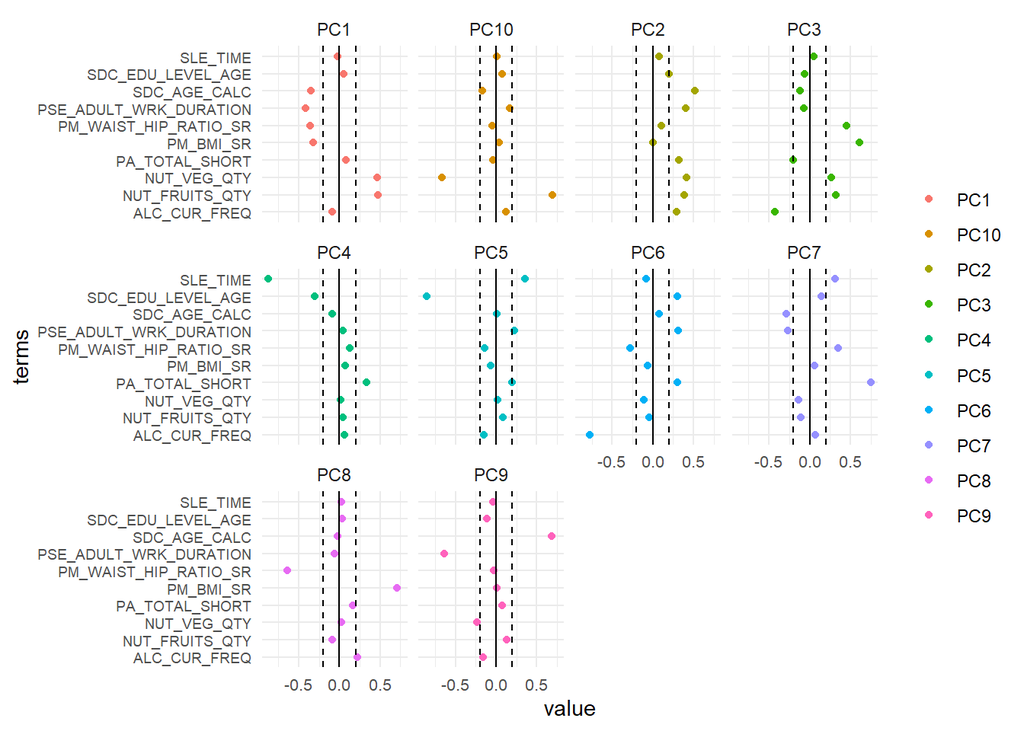

```r
ggplot(pca_variables) +
  geom_point(aes(x = value, y = terms, color = component))+
  labs(color = NULL) +
  geom_vline(xintercept=0) +
  geom_vline(xintercept=-0.2, linetype = 'dashed') +
  geom_vline(xintercept=0.2, linetype = 'dashed') +
  facet_wrap(~ component) +
  theme_minimal() +
  theme(
    axis.text.y = element_text(size = 07),
    axis.text.x = element_text(size = 08)
          )
```

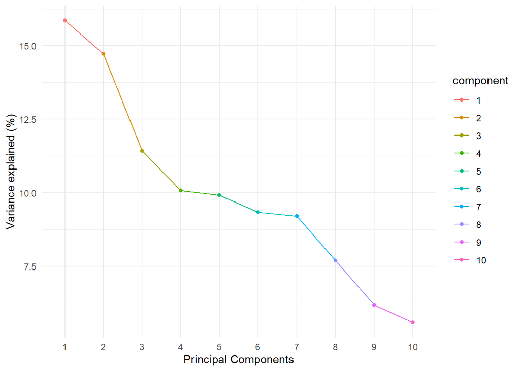

```r
# Component loadings- variance (how much variance each variable explains in each component)


pca_variances <- tidy(pca_prepared, id = "pca_id", type = "variance")

pca_variance <- pca_variances |> filter(terms == "percent variance")
pca_variance$component <- as.factor(pca_variance$component)
pca_variance$comp <- as.numeric(pca_variance$component)

ggplot(pca_variance, aes(x = component, y = value, group = 1, color = component)) +
  geom_point() +
  geom_line() +
  labs(x = "Principal Components", y = "Variance explained (%)") +
  theme_minimal()
```

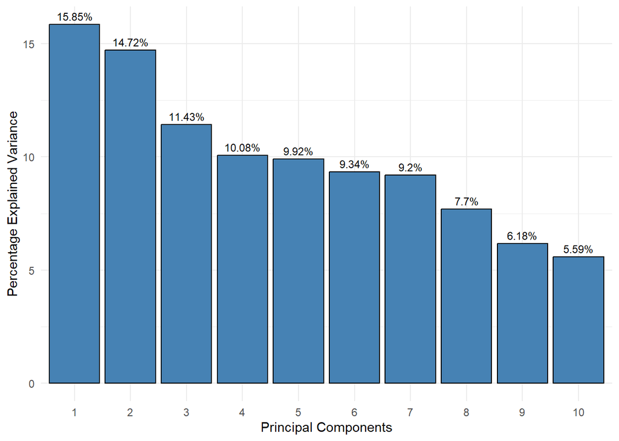

```r
# Bar Chart for explained variance

pca_variance2 <-ggplot(pca_variance, aes(x = component, y = value)) +
  geom_bar(stat = "identity", fill = "steelblue", color = "black") +
  geom_text(aes(label = paste0(round(value, 2), "%")), vjust = -0.5, size = 3) +
  labs(x = "Principal Components", y = "Percentage Explained Variance") +
  theme_minimal()

pca_variance2
```

**Interpretation:** PC1, PC2, PC3 could be viewed as the strongest components as they represent the largest (> 40%) of the variation in the data.

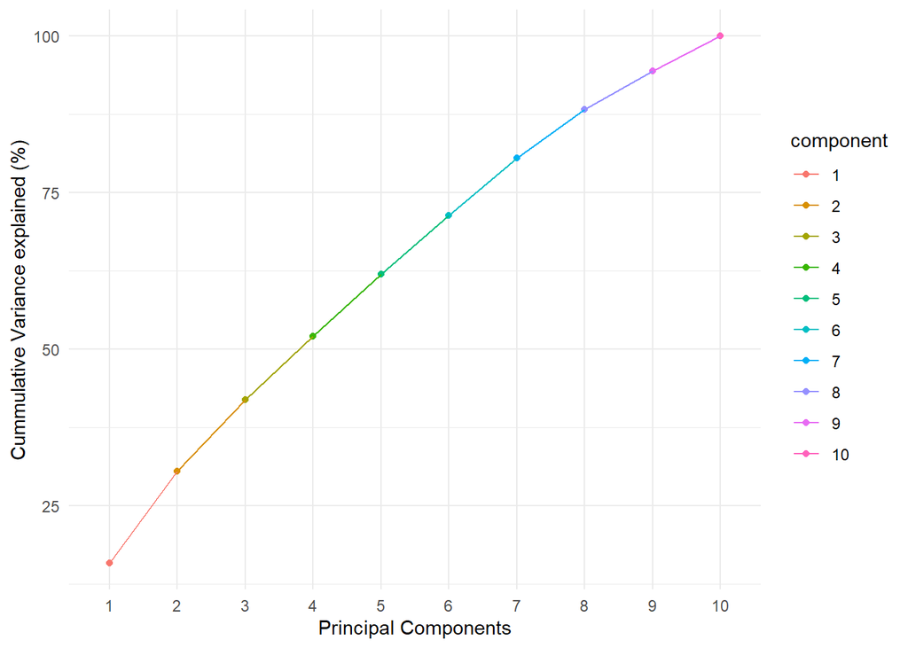

```r
# Cumulative percent variance

pca_cummul_variance <- pca_variances |> filter(terms == "cumulative percent variance")
pca_cummul_variance$component <- as.factor(pca_cummul_variance$component)
pca_cummul_variance$comp <- as.numeric(pca_cummul_variance$component)

ggplot(pca_cummul_variance, aes(x = component, y = value, group = 1, color = component)) +
  geom_point() +
  geom_line() +
  labs(x = "Principal Components", y = "Cummulative Variance explained (%)") +
  theme_minimal()
```

**Interpretation:** The cumulative variance plot shows PC1 to PC4 explain about 50% of the variance and PC1 to PC7 explain about 80% of the variance.

```
## Correlation computed with
## • Method: 'pearson'
## • Missing treated using: 'pairwise.complete.obs'
```

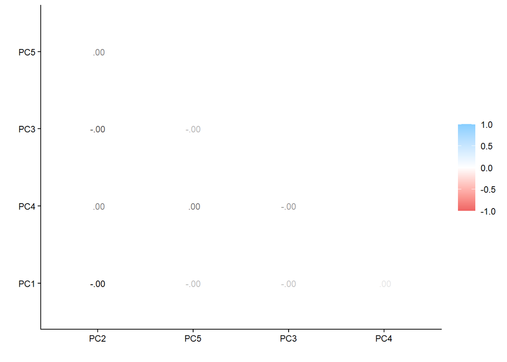

```r
# Checking the correlation between the components

pca_corr <- pca_baked |> dplyr:: select(!ID)

pca_corr %>%
  correlate() %>%
  rearrange() %>%
  shave()  %>%
  rplot(print_cor=TRUE)
```

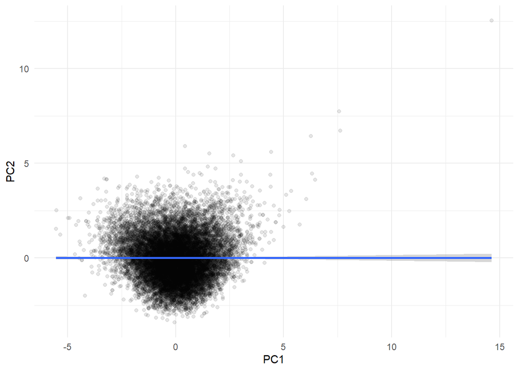

```r
ggplot(pca_baked, aes(x = PC1, y = PC2)) +
  geom_point(alpha = 0.1) +
  geom_smooth(method = "lm") +
  labs(x = "PC1", y = "PC2") +
  theme_minimal()
```

**Interpretation:** The correlation plot shows that the principal components are uncorrelated with each other. The scatter plot of PC1 vs. PC2 also shows no clear linear relationship between these two components, which is consistent with the correlation plot.

### Q-3: Cluster Selection Tuning

```r
data_clus <- data
```

```r
set.seed(10)

### Model
kmeans_model <- k_means(num_clusters = 3) |>
                  set_engine("stats")
kmeans_model
```

```
## K Means Cluster Specification (partition)
##
## Main Arguments:
##   num_clusters = 3
##
## Computational engine: stats
```

```r
### Recipe

kmeans_recipe <- recipe(~ ., data = data_clus) %>%
  update_role(ID, new_role = "id") %>%
  step_zv(all_predictors()) %>%
  step_center(all_numeric_predictors()) %>%
  step_scale(all_numeric_predictors())


kmeans_recipe
```

```
## ── Recipe ──────────────────────────────────────────────────────────────────────
```

```
## ── Inputs
```

```
## Number of variables by role
```

```
## predictor: 10
## id:         1
```

```
## ── Operations
```

```
## • Zero variance filter on: all_predictors()
```

```
## • Centering for: all_numeric_predictors()
```

```
## • Scaling for: all_numeric_predictors()
```

```r
### Workflow

set.seed(10)

kmeans_workflow <- workflow() |>
    add_recipe(kmeans_recipe) |>
    add_model(kmeans_model)
```

```r
### Fit the model

set.seed(10)

kmeans_fit <- kmeans_workflow |> fit(data=data_clus)

kmeans_fit
```

```
## ══ Workflow [trained] ══════════════════════════════════════════════════════════
## Preprocessor: Recipe
## Model: k_means()
##
## ── Preprocessor ────────────────────────────────────────────────────────────────
## 3 Recipe Steps
##
## • step_zv()
## • step_center()
## • step_scale()
##
## ── Model ───────────────────────────────────────────────────────────────────────
## K-means clustering with 3 clusters of sizes 6832, 4702, 4547
##
## Cluster means:
##   SDC_AGE_CALC PA_TOTAL_SHORT   PM_BMI_SR SDC_EDU_LEVEL_AGE
## 3  -0.60029403     -0.2790017 -0.04116033      -0.150879432
## 2   0.09090333      0.3030686 -0.27827646       0.216568358
## 1   0.80795720      0.1058085  0.34960706       0.002749914
##   PSE_ADULT_WRK_DURATION PM_WAIST_HIP_RATIO_SR     SLE_TIME NUT_VEG_QTY
## 3             -0.4598530            -0.1142339 -0.092227324  -0.3978773
## 2             -0.2789403            -0.2370908  0.002184849   0.9200348
## 1              0.9793914             0.4168127  0.136314914  -0.3535751
##   NUT_FRUITS_QTY ALC_CUR_FREQ
## 3     -0.3814658   -0.3392794
## 2      0.9186541    0.1792766
## 1     -0.3768061    0.3243894
##
## Clustering vector:
##     [1] 1 1 1 2 2 1 3 1 1 3 3 1 1 1 1 2 1 1 2 2 1 1 3 2 2 3 1 3 2 3 1 3 1 3 1 2
##    [37] 3 3 2 2 3 3 2 3 3 1 1 1 3 3 1 2 1 1 3 2 3 1 1 2 1 2 3 3 1 2 1 3 1 2 1 1
##    [73] 2 1 1 1 3 3 1 3 3 3 3 3 1 1 1 1 3 3 2 2 3 2 1 3 2 1 3 1 1 3 1 2 1 1 1 2
##   [109] 1 3 2 1 3 2 2 1 2 2 1 3 3 1 1 1 1 1 1 3 3 1 2 1 1 3 1 1 3 1 1 1 3 3 1 3
##   [145] 3 1 1 1 1 3 3 1 1 1 3 2 1 1 2 2 2 3 2 1 2 1 2 1 3 3 2 3 1 1 1 2 1 1 3 1
##   [181] 1 1 1 1 1 1 2 2 1 1 1 1 1 1 1 1 1 2 3 3 2 1 1 1 1 3 1 3 1 1 2 2 3 2 1 1
##   [217] 3 3 2 1 2 1 3 1 2 1 3 1 3 2 1 2 3 1 3 1 1 1 1 2 3 1 3 1 2 1 2 3 2 3 1 3
##   [253] 3 3 1 2 2 1 2 3 1 2 2 3 2 2 3 2 1 2 2 2 1 3 3 3 3 3 2 1 1 1 2 1 1 3 3 3
##   [289] 1 3 3 3 3 1 1 1 3 1 3 1 1 3 3 1 2 3 1 3 3 2 1 3 2 1 3 1 1 1 3 1 2 2 1 1
##   [325] 3 2 1 1 2 1 2 2 2 1 1 1 1 1 1 1 2 1 1 1 2 1 1 3 1 1 2 2 1 1 1 1 1 3 2 3
##   [361] 1 1 1 2 1 1 1 3 2 3 1 3 3 1 1 1 3 2 1 3 1 1 1 2 1 3 3 1 2 3 1 1 1 1 3 1
```

[output cut: 10 more lines]

```
##   [757] 1 1 1 1 1 1 1 1 1 2 2 3 1 2 3 2 3 1 1 1 1 1 1 1 1 1 3 1 3 2 3 1 2 3 3 3
##   [793] 3 1 1 3 1 1 1 1 2 1 1 2 3 1 2 1 1 1 2 1 2 2 1 2 1 1 3 3 3 1 1 3 1 1 2 3
##   [829] 3 1 2 2 1 1 2 1 1 2 3 3 1 1 1 2 1 2 3 2 1 2 1 2 2 3 2 1 3 1 1 3 3 3 2 3
##   [865] 1 3 2 1 1 3 3 2 1 3 3 1 1 1 1 1 2 1 3 3 1 3 2 1 3 2 2 3 2 2 1 1 3 2 1 1
##   [901] 1 1 3 1 2 1 2 1 2 1 1 1 2 2 2 1 1 1 3 2 3 2 1 3 3 1 1 3 2 2 1 3 1 1 1 2
##   [937] 1 1 2 1 1 1 3 2 1 1 1 2 2 1 3 1 1 1 1 2 2 1 3 3 1 1 2 3 3 1 3 1 1 3 3 2
##   [973] 2 3 1 3 1 2 2 1 1 1 1 1 1 2 1 1 3 2 1 3 1 1 1 1 1 1 2 1 3 3 1 3 3 1 1 1
##  [1009] 2 1 1 1 3 2 1 3 2 2 1 1 3 2 3 1 2 1 2 3 1 1 2 2 1 1 1 1 1 3 2 3 3 3 3 1
##  [1045] 1 1 3 3 2 1 1 1 2 1 1 1 2 3 2 1 1 3 1 1 1 1 3 1 1 1 2 3 1 1 1 3 1 1 1 1
##  [1081] 2 1 2 1 1 1 3 1 1 1 2 1 1 2 1 1 1 2 1 2 1 3 1 1 1 3 2 1 1 2 1 1 3 2 1 3
##  [1117] 2 1 2 2 1 1 3 1 3 2 2 2 3 3 1 1 2 1 1 2 2 1 1 3 1 1 1 1 2 3 2 1 1 3 2 3
##  [1153] 3 3 1 2 2 2 3 2 1 3 1 1 2 3 1 1 1 1 1 1 1 1 2 2 1 2 2 1 1 3 3 2 1 3 2 3
##
## ...
## and 423 more lines.
```

```r
# save the cluster

clusters <-kmeans_fit |> extract_cluster_assignment()
clusters <- as.data.frame(clusters)

names(clusters) <- c("cluster")
data_clus$clusters <- clusters$cluster
```

```r
# Check the cluster assignments

summary(data_clus$clusters)
```

```
## Cluster_1 Cluster_2 Cluster_3
##      6832      4702      4547
```

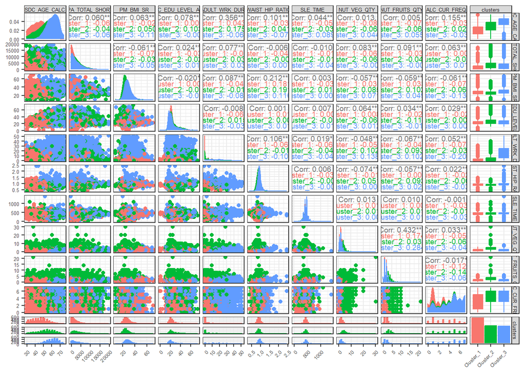

```r
# Visualization

data_clus %>%
    dplyr::select(c(SDC_AGE_CALC, PA_TOTAL_SHORT, PM_BMI_SR, SDC_EDU_LEVEL_AGE, PSE_ADULT_WRK_DURATION, PM_WAIST_HIP_RATIO_SR, SLE_TIME, NUT_VEG_QTY, NUT_FRUITS_QTY, ALC_CUR_FREQ, clusters)) |>

ggpairs(aes(fill = clusters, color = clusters), upper = list(continuous = wrap("cor", size = 2.5))) +
  theme_bw() +
  theme(
    strip.text = element_text(size = 5, margin = margin(1,1,1,1)),
    axis.text.x = element_text(angle = 45, hjust = 1, vjust = 1, size = 5),
    axis.text.y = element_text(size = 5),
    axis.title  = element_text(size = 7),
    legend.text = element_text(size = 6),
    legend.title = element_text(size = 7),
    panel.spacing = unit(0.2, "lines")
  )
```

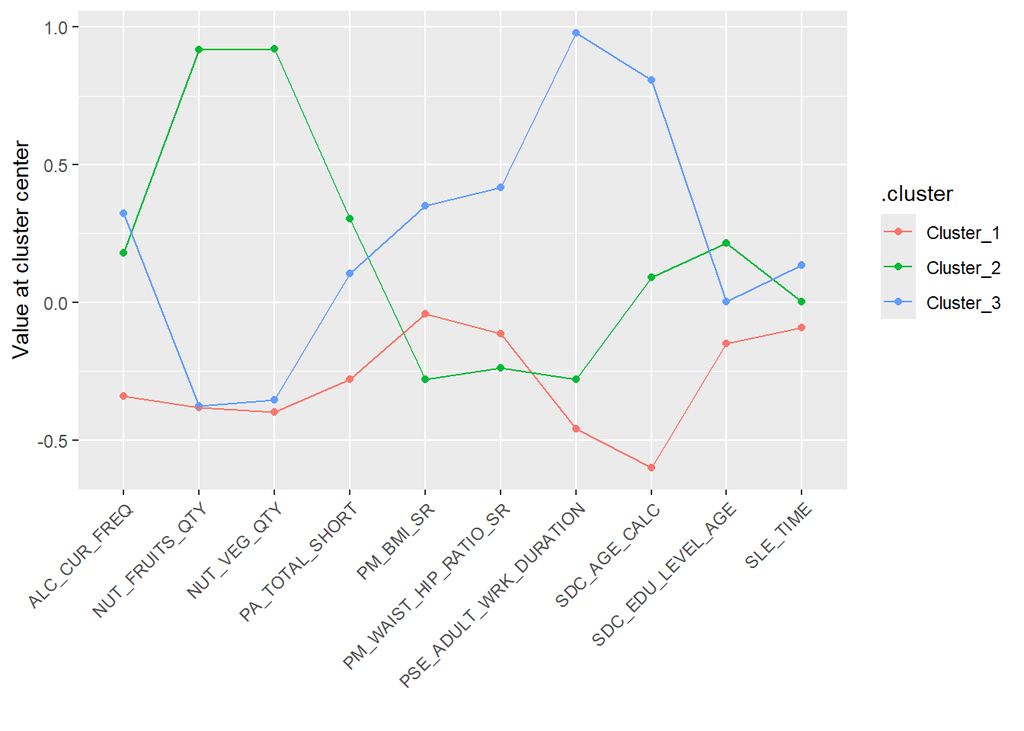

```r
# The centroid of each cluster for each variable
centroids <- extract_centroids(kmeans_fit)
centroids_long <- centroids %>% pivot_longer(cols=c("SDC_AGE_CALC", "PA_TOTAL_SHORT", "PM_BMI_SR", "SDC_EDU_LEVEL_AGE", "PSE_ADULT_WRK_DURATION", "PM_WAIST_HIP_RATIO_SR", "SLE_TIME", "NUT_VEG_QTY", "NUT_FRUITS_QTY", "ALC_CUR_FREQ"))



ggplot(data = centroids_long, aes(x = name, y = value, group = .cluster, color = .cluster)) +
    geom_point() +
    geom_line() +
    labs(x="", y="Value at cluster center") +
  theme(axis.text.x = element_text(angle=45, hjust = 1))
```

**Interpretation:** Cluster 1 may likely represent a younger, low education, low PA, and low fruit and vegitable consumption group with moderate BMI and waist circumference. Cluster 2 represents educated groups with health lifestyle (higher physical activity, higher fruit and vegitable consumption) and lower BMI and waist circumference. Cluster 3 represents older and busy group with higher BMI and waist circumference, moderate physical activity and poor dietary practice (low consumption of fruit and vegitables and high alcohol consumption).

```r
# How many clusters- Model with tuning of cluster #

kmeans_model_tune <- k_means(num_clusters = tune()) %>%
                  set_engine("stats")
```

```r
# Workflow

kmodes_workflow_tune <- workflow() %>%
    add_recipe(kmeans_recipe) %>%
    add_model(kmeans_model_tune)

folds <- vfold_cv(data, v = 2)
grid <- tibble(num_clusters=1:10)
```

```r
tuned_model <- tune_cluster(kmodes_workflow_tune,
                        resamples = folds,
                        grid = grid,
                       metrics = cluster_metric_set(silhouette_avg),
                       control = control_resamples(save_pred = TRUE,
                                                  verbose = TRUE,
                                                  parallel_over = "everything")
                       )
```

[output not shown]

[output not shown]

[output not shown]

[output not shown]

[output not shown]

[output not shown]

[output not shown]

[output not shown]

[output not shown]

[output not shown]

[output not shown]

[output not shown]

[output not shown]

[output not shown]

[output not shown]

[output not shown]

[output not shown]

[output not shown]

[output not shown]

[output not shown]

[output not shown]

[output not shown]

[output not shown]

[output not shown]

[output not shown]

[output not shown]

[output not shown]

[output not shown]

[output not shown]

[output not shown]

[output not shown]

[output not shown]

[output not shown]

[output not shown]

[output not shown]

[output not shown]

[output not shown]

[output not shown]

[output not shown]

[output not shown]

[output not shown]

[output not shown]

[output not shown]

[output not shown]

[output not shown]

[output not shown]

[output not shown]

[output not shown]

[output not shown]

[output not shown]

[output not shown]

[output not shown]

[output not shown]

[output not shown]

[output not shown]

[output not shown]

[output not shown]

[output not shown]

[output not shown]

[output not shown]

[output not shown]

[output not shown]

[output not shown]

[output not shown]

[output not shown]

[output not shown]

[output not shown]

[output not shown]

[output not shown]

[output not shown]

[output not shown]

[output not shown]

[output not shown]

[output not shown]

[output not shown]

[output not shown]

[output not shown]

[output not shown]

[output not shown]

[output not shown]

[output not shown]

[output not shown]

[output not shown]

[output not shown]

[output not shown]

[output not shown]

[output not shown]

[output not shown]

[output not shown]

[output not shown]

[output not shown]

[output not shown]

[output not shown]

[output not shown]

[output not shown]

[output not shown]

[output not shown]

[output not shown]

[output not shown]

[output not shown]

```r
collect_metrics(tuned_model) %>% head()
```

```
## # A tibble: 6 × 7
##   num_clusters .metric        .estimator     mean     n   std_err .config
##          <int> <chr>          <chr>         <dbl> <int>     <dbl> <chr>
## 1            1 silhouette_avg standard   NaN          0 NA        Preprocessor1…
## 2            2 silhouette_avg standard     0.109      2  0.000145 Preprocessor1…
## 3            3 silhouette_avg standard     0.103      2  0.000438 Preprocessor1…
## 4            4 silhouette_avg standard     0.107      2  0.00279  Preprocessor1…
## 5            5 silhouette_avg standard     0.0905     2  0.00297  Preprocessor1…
## 6            6 silhouette_avg standard     0.0962     2  0.00110  Preprocessor1…
```

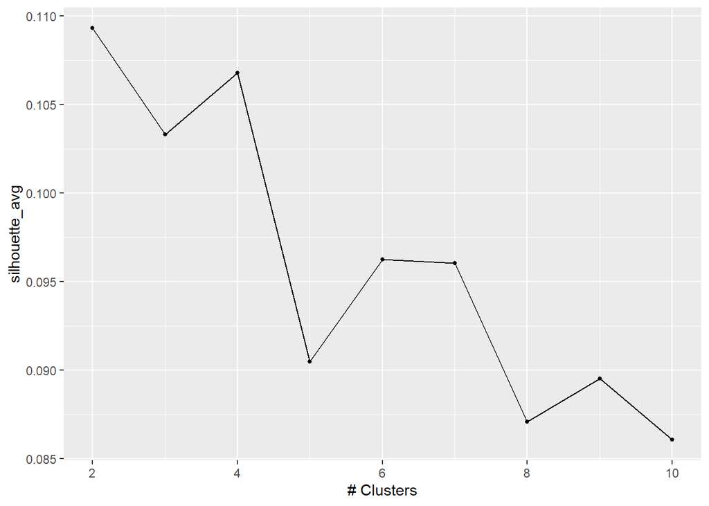

```r
autoplot(tuned_model)
```

#### Cluster tunning with 4 clusters

```r
data_2 <- data_clus %>% dplyr::select(-clusters)
```

```r
set.seed(10)

### Model
kmeans_model_final <- k_means(num_clusters = 4) %>%
                  set_engine("stats")
kmeans_model_final
```

```
## K Means Cluster Specification (partition)
##
## Main Arguments:
##   num_clusters = 4
##
## Computational engine: stats
```

```r
### Recipe

kmeans_recipe_final <- recipe(~ ., data = data_2) |>
  update_role(ID, new_role = "id") |>
  step_zv(all_predictors()) |>
  step_center(all_numeric_predictors()) |>
  step_scale(all_numeric_predictors())
kmeans_recipe_final
```

```
## ── Recipe ──────────────────────────────────────────────────────────────────────
```

```
## ── Inputs
```

```
## Number of variables by role
```

```
## predictor: 10
## id:         1
```

```
## ── Operations
```

```
## • Zero variance filter on: all_predictors()
```

```
## • Centering for: all_numeric_predictors()
```

```
## • Scaling for: all_numeric_predictors()
```

```r
### Workflow

set.seed(10)

kmeans_workflow_final <- workflow() |>
    add_recipe(kmeans_recipe_final) |>
    add_model(kmeans_model_final)
```

```r
### Fit the model

set.seed(10)

kmeans_fit_final <- kmeans_workflow_final |> fit(data=data_2)

kmeans_fit_final
```

```
## ══ Workflow [trained] ══════════════════════════════════════════════════════════
## Preprocessor: Recipe
## Model: k_means()
##
## ── Preprocessor ────────────────────────────────────────────────────────────────
## 3 Recipe Steps
##
## • step_zv()
## • step_center()
## • step_scale()
##
## ── Model ───────────────────────────────────────────────────────────────────────
## K-means clustering with 4 clusters of sizes 6265, 4134, 1928, 3754
##
## Cluster means:
##   SDC_AGE_CALC PA_TOTAL_SHORT   PM_BMI_SR SDC_EDU_LEVEL_AGE
## 3  -0.61627442    -0.38703052 -0.02560769       -0.14273803
## 4   0.07553139    -0.09854083 -0.27221208        0.21367933
## 2   0.23108029     1.97752367 -0.13863213        0.12016614
## 1   0.82663549    -0.26120182  0.41370262       -0.05881111
##   PSE_ADULT_WRK_DURATION PM_WAIST_HIP_RATIO_SR      SLE_TIME NUT_VEG_QTY
## 3            -0.46989449           -0.09949920 -0.0824999517  -0.4115122
## 4            -0.30050767           -0.24129016 -0.0005168214   0.9785524
## 2             0.05873319           -0.06549839 -0.0844805445  -0.1009493
## 1             1.08496273            0.46540673  0.1816401777  -0.3389935
##   NUT_FRUITS_QTY ALC_CUR_FREQ
## 3     -0.4044846   -0.3268401
## 4      0.9686566    0.1655247
## 2     -0.0502576    0.1718467
## 1     -0.3658587    0.2749211
##
## Clustering vector:
##     [1] 1 1 1 2 2 1 3 1 1 4 4 1 1 1 1 3 1 1 3 3 1 1 3 3 2 4 1 4 2 4 1 4 1 3 1 2
##    [37] 4 4 2 3 3 4 2 4 4 1 1 1 4 4 3 2 1 1 3 3 4 1 1 3 1 2 3 4 1 2 1 3 1 2 1 1
##    [73] 2 1 1 1 4 4 2 4 4 4 4 4 1 1 1 1 3 4 2 2 4 2 1 4 2 1 4 1 1 4 1 2 1 1 1 2
##   [109] 1 4 2 2 4 2 2 1 2 2 1 3 3 1 1 1 1 4 1 4 4 1 2 3 1 4 1 1 4 1 1 1 4 3 1 4
##   [145] 4 1 1 1 1 4 4 1 1 3 4 2 1 1 2 2 2 4 2 2 2 1 2 1 4 4 2 1 1 1 1 2 1 1 4 1
##   [181] 1 2 1 1 1 1 2 2 1 1 1 1 1 1 1 1 1 2 4 4 2 3 1 1 3 4 1 4 1 1 2 2 3 2 1 1
##   [217] 3 4 2 1 2 3 4 1 2 1 4 1 4 2 1 2 4 1 4 1 1 1 1 2 4 1 4 1 2 1 2 3 2 4 1 4
##   [253] 3 4 1 2 2 1 2 4 1 2 2 4 2 2 4 2 1 2 2 2 2 4 4 4 4 4 2 1 1 3 3 1 1 3 4 4
```

[output cut: 10 more lines]

```
##   [649] 1 3 1 1 1 4 1 3 2 1 1 2 1 1 1 2 2 2 2 1 2 1 1 4 2 3 4 3 1 1 2 1 1 4 2 1
##   [685] 2 3 4 1 2 1 1 1 1 4 1 4 1 2 4 2 4 1 1 4 2 4 1 1 3 3 1 2 4 3 1 1 1 4 2 1
##   [721] 4 2 1 2 3 2 1 4 1 1 1 1 3 4 1 4 1 1 1 1 1 2 1 2 1 1 4 2 1 2 1 2 4 1 1 1
##   [757] 1 1 1 1 1 1 1 1 1 2 2 4 1 3 4 2 4 1 1 1 3 1 1 1 1 1 4 1 4 2 3 1 2 4 4 4
##   [793] 4 1 3 3 1 1 1 1 2 1 1 2 3 1 2 1 1 1 2 1 2 2 1 2 1 1 4 4 4 1 1 4 1 1 3 4
##   [829] 4 1 3 2 1 1 2 1 1 3 4 4 1 1 1 2 1 2 4 2 1 2 1 3 3 4 2 1 4 1 2 4 3 3 2 4
##   [865] 1 4 2 3 1 1 4 2 1 4 3 1 1 1 1 1 2 1 1 4 1 4 2 1 4 3 2 4 2 2 1 1 4 2 1 1
##   [901] 1 1 4 1 2 1 2 1 2 1 1 1 2 2 2 1 1 1 4 2 4 2 1 4 4 1 3 4 2 2 1 4 1 1 1 2
##   [937] 1 1 2 1 1 2 4 2 1 1 1 2 2 1 4 1 1 1 1 2 2 1 4 4 1 1 3 4 4 1 4 1 1 3 4 2
##   [973] 3 3 1 4 1 2 2 3 1 1 1 1 3 3 1 1 4 3 1 4 1 1 1 1 1 1 2 1 4 4 1 4 4 1 1 1
##  [1009] 2 1 1 2 3 2 1 4 2 3 1 1 4 2 4 1 2 1 2 4 1 1 2 2 2 1 1 1 1 3 2 4 4 4 3 1
##  [1045] 3 1 4 4 3 1 1 1 2 1 1 1 2 4 2 1 1 3 1 1 1 4 4 1 1 1 2 4 1 1 1 4 1 1 1 1
##
## ...
## and 426 more lines.
```

```r
# save the cluster

clusters <-kmeans_fit_final |> extract_cluster_assignment()
clusters <- as.data.frame(clusters)

names(clusters) <- c("cluster")
data_2$clusters <- clusters$cluster
```

```r
# Workflow

kmodes_workflow_tune <- workflow() %>%
    add_recipe(kmeans_recipe_final) %>%
    add_model(kmeans_model_tune)

folds <- vfold_cv(data, v = 2)
grid <- tibble(num_clusters=1:10)
```

```r
tuned_model <- tune_cluster(kmodes_workflow_tune,
                        resamples = folds,
                        grid = grid,
                       metrics = cluster_metric_set(silhouette_avg),
                       control = control_resamples(save_pred = TRUE,
                                                  verbose = TRUE,
                                                  parallel_over = "everything")
                       )
```

[output not shown]

[output not shown]

[output not shown]

[output not shown]

[output not shown]

[output not shown]

[output not shown]

[output not shown]

[output not shown]

[output not shown]

[output not shown]

[output not shown]

[output not shown]

[output not shown]

[output not shown]

[output not shown]

[output not shown]

[output not shown]

[output not shown]

[output not shown]

[output not shown]

[output not shown]

[output not shown]

[output not shown]

[output not shown]

[output not shown]

[output not shown]

[output not shown]

[output not shown]

[output not shown]

[output not shown]

[output not shown]

[output not shown]

[output not shown]

[output not shown]

[output not shown]

[output not shown]

[output not shown]

[output not shown]

[output not shown]

[output not shown]

[output not shown]

[output not shown]

[output not shown]

[output not shown]

[output not shown]

[output not shown]

[output not shown]

[output not shown]

[output not shown]

[output not shown]

[output not shown]

[output not shown]

[output not shown]

[output not shown]

[output not shown]

[output not shown]

[output not shown]

[output not shown]

[output not shown]

[output not shown]

[output not shown]

[output not shown]

[output not shown]

[output not shown]

[output not shown]

[output not shown]

[output not shown]

[output not shown]

[output not shown]

[output not shown]

[output not shown]

[output not shown]

[output not shown]

[output not shown]

[output not shown]

[output not shown]

[output not shown]

[output not shown]

[output not shown]

[output not shown]

[output not shown]

[output not shown]

[output not shown]

[output not shown]

[output not shown]

[output not shown]

[output not shown]

[output not shown]

[output not shown]

[output not shown]

[output not shown]

[output not shown]

[output not shown]

[output not shown]

[output not shown]

[output not shown]

[output not shown]

[output not shown]

[output not shown]

[output not shown]

```r
collect_metrics(tuned_model) %>% head()
```

```
## # A tibble: 6 × 7
##   num_clusters .metric        .estimator     mean     n   std_err .config
##          <int> <chr>          <chr>         <dbl> <int>     <dbl> <chr>
## 1            1 silhouette_avg standard   NaN          0 NA        Preprocessor1…
## 2            2 silhouette_avg standard     0.109      2  0.000744 Preprocessor1…
## 3            3 silhouette_avg standard     0.103      2  0.00179  Preprocessor1…
## 4            4 silhouette_avg standard     0.109      2  0.000460 Preprocessor1…
## 5            5 silhouette_avg standard     0.0956     2  0.000340 Preprocessor1…
## 6            6 silhouette_avg standard     0.0997     2  0.00764  Preprocessor1…
```

### Q-4-1: Linear regression based on Baseline PCA Model

```r
set.seed(10)

# Create a split object

data_split <- initial_split(data, prop = 0.70)

# Build training data set

train_data <- training(data_split)
summary(train_data$PM_BMI_SR)
```

```
##    Min. 1st Qu.  Median    Mean 3rd Qu.    Max.
##    8.86   23.41   26.50   27.40   30.23   69.40
```

```r
# Build testing data set

test_data  <- testing(data_split)
summary(test_data$PM_BMI_SR)
```

```
##    Min. 1st Qu.  Median    Mean 3rd Qu.    Max.
##    8.86   23.24   26.43   27.28   30.24   61.32
```

```r
# Model specification

linear_model <- linear_reg() |>
        set_engine("glm") |>
        set_mode("regression")

# View object properties

linear_model
```

```
## Linear Regression Model Specification (regression)
##
## Computational engine: glm
```

```r
# Recipe for regression

pca_reg_recipe <- recipe(PM_BMI_SR ~., data = train_data) |>
  update_role(ID, new_role = "id") |>
  step_scale(all_numeric_predictors()) |>
  step_center(all_numeric_predictors()) |>
  step_pca(all_numeric_predictors(), num_comp = 7, id = "pca_id") |>
  step_zv(all_predictors())

pca_reg_recipe
```

```
## ── Recipe ──────────────────────────────────────────────────────────────────────
```

```
## ── Inputs
```

```
## Number of variables by role
```

```
## outcome:   1
## predictor: 9
## id:        1
```

```
## ── Operations
```

```
## • Scaling for: all_numeric_predictors()
```

```
## • Centering for: all_numeric_predictors()
```

```
## • PCA extraction with: all_numeric_predictors()
```

```
## • Zero variance filter on: all_predictors()
```

```r
# Workflow

bmi_workflow <-
        workflow() %>%
        add_model(linear_model) %>%
        add_recipe(pca_reg_recipe)

bmi_workflow
```

```
## ══ Workflow ════════════════════════════════════════════════════════════════════
## Preprocessor: Recipe
## Model: linear_reg()
##
## ── Preprocessor ────────────────────────────────────────────────────────────────
## 4 Recipe Steps
##
## • step_scale()
## • step_center()
## • step_pca()
## • step_zv()
##
## ── Model ───────────────────────────────────────────────────────────────────────
## Linear Regression Model Specification (regression)
##
## Computational engine: glm
```

```r
# Fit the model

bmi_fit <-
  bmi_workflow |>
  fit(data = train_data)
```

```r
options(scipen = 999, digits = 3)

bmi_fit_extract <- bmi_fit |>
                    extract_fit_parsnip() |>
                    tidy()
bmi_fit_extract
```

```
## # A tibble: 8 × 5
##   term        estimate std.error statistic  p.value
##   <chr>          <dbl>     <dbl>     <dbl>    <dbl>
## 1 (Intercept)  27.4       0.0537   510.    0
## 2 PC1           0.723     0.0435    16.6   3.00e-61
## 3 PC2           0.0144    0.0442     0.326 7.44e- 1
## 4 PC3           0.338     0.0533     6.35  2.25e-10
## 5 PC4          -0.228     0.0540    -4.23  2.40e- 5
## 6 PC5           0.974     0.0546    17.8   2.80e-70
## 7 PC6           0.312     0.0554     5.62  1.91e- 8
## 8 PC7          -0.341     0.0561    -6.07  1.28e- 9
```

```r
# Predictions

bmi_predicted <- augment(bmi_fit, test_data)

bmi_predicted
```

```
## # A tibble: 4,825 × 13
##    .pred .resid ID       SDC_AGE_CALC PA_TOTAL_SHORT PM_BMI_SR SDC_EDU_LEVEL_AGE
##    <dbl>  <dbl> <chr>           <dbl>          <dbl>     <dbl>             <dbl>
##  1  29.0 -0.691 SYN_586…           57             0       28.3                22
##  2  26.9 -3.01  SYN_586…           36          2118       23.8                22
##  3  26.3  6.50  SYN_586…           63           297       32.8                27
##  4  25.1  3.17  SYN_586…           45          4158       28.3                24
##  5  28.6  4.48  SYN_586…           54          1964.      33.1                20
##  6  28.5  1.89  SYN_586…           48             0       30.4                19
##  7  28.1  4.12  SYN_586…           54          1386       32.2                21
##  8  25.5 -1.20  SYN_586…           47          5382       24.3                35
##  9  29.4 14.0   SYN_586…           55          1390       43.4                21
## 10  27.4 -0.832 SYN_586…           46           960       26.6                41
## # ℹ 4,815 more rows
## # ℹ 6 more variables: PSE_ADULT_WRK_DURATION <dbl>,
## #   PM_WAIST_HIP_RATIO_SR <dbl>, SLE_TIME <dbl>, NUT_VEG_QTY <dbl>,
## #   NUT_FRUITS_QTY <dbl>, ALC_CUR_FREQ <dbl>
```

```r
pred_bmi <- predict(bmi_fit,
                      new_data = test_data)
summary(pred_bmi$.pred)
```

```
##    Min. 1st Qu.  Median    Mean 3rd Qu.    Max.
##    21.0    26.5    27.4    27.4    28.3    43.0
```

```r
summary(test_data$PM_BMI_SR)
```

```
##    Min. 1st Qu.  Median    Mean 3rd Qu.    Max.
##    8.86   23.24   26.43   27.28   30.24   61.32
```

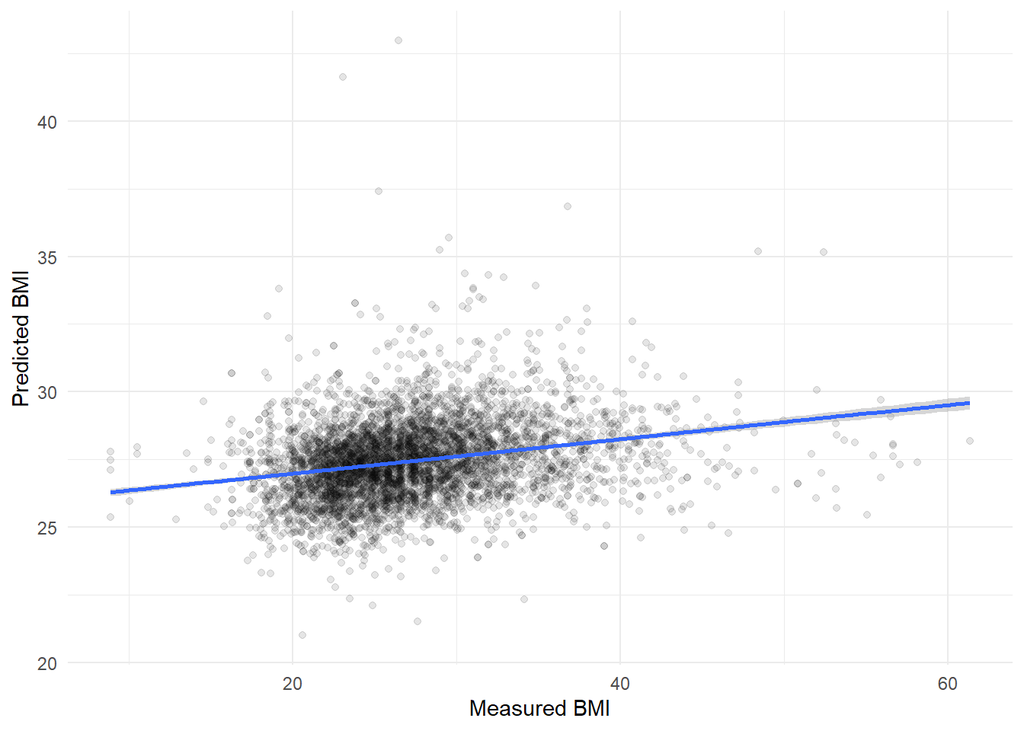

```r
ggplot(bmi_predicted, aes(x = PM_BMI_SR, y = .pred)) +
  geom_point(alpha = 0.1) +
  geom_smooth(method = "lm") +
  labs(x = "Measured BMI", y = "Predicted BMI") +
  theme_minimal()
```

```r
## Quick check of the predictions

pred_true <- test_data |>
  dplyr::select(PM_BMI_SR) |>
  bind_cols(pred_bmi)

head(pred_true)
```

```
## # A tibble: 6 × 2
##   PM_BMI_SR .pred
##       <dbl> <dbl>
## 1      28.3  29.0
## 2      23.8  26.9
## 3      32.8  26.3
## 4      28.3  25.1
## 5      33.1  28.6
## 6      30.4  28.5
```

##### Model evaluation

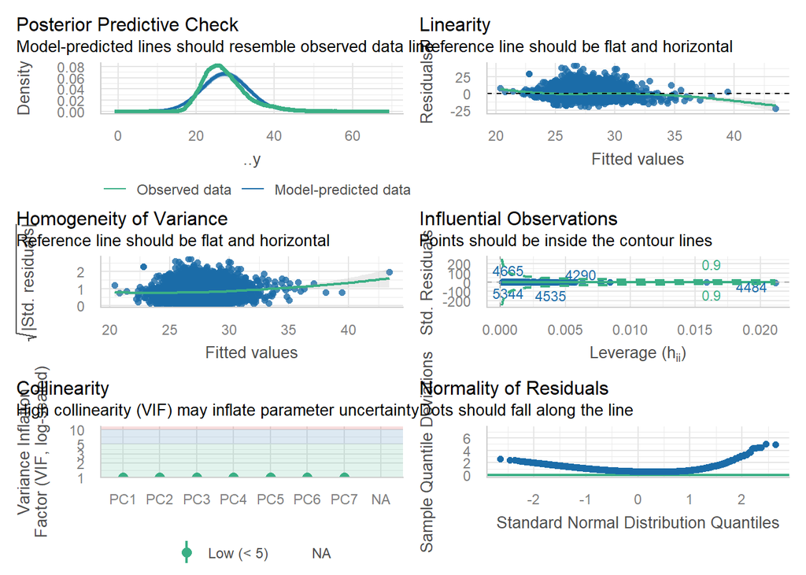

```r
bmi_fit |>
  extract_fit_engine() |>
  check_model()
```

```r
rsq(pred_true, truth = PM_BMI_SR,
         estimate = .pred)
```

```
## # A tibble: 1 × 3
##   .metric .estimator .estimate
##   <chr>   <chr>          <dbl>
## 1 rsq     standard      0.0605
```

#### Q-4-2: Linear regression with tuning of cluster

```r
set.seed(10)

# Create a split object
data_split_2 <- initial_split(data_2, prop = 0.70)

# Build training data set
train_data_2 <- training(data_split_2)
summary(train_data_2$PM_BMI_SR)
```

```
##    Min. 1st Qu.  Median    Mean 3rd Qu.    Max.
##    8.86   23.41   26.50   27.40   30.23   69.40
```

```r
table(train_data_2$clusters)
```

```
##
## Cluster_1 Cluster_2 Cluster_3 Cluster_4
##      4402      2869      1351      2634
```

```r
# Build testing data set
test_data_2  <- testing(data_split_2)
summary(test_data_2$PM_BMI_SR)
```

```
##    Min. 1st Qu.  Median    Mean 3rd Qu.    Max.
##    8.86   23.24   26.43   27.28   30.24   61.32
```

```r
table(test_data_2$clusters)
```

```
##
## Cluster_1 Cluster_2 Cluster_3 Cluster_4
##      1863      1265       577      1120
```

```r
# Model specification
linear_model_2 <- linear_reg() |>
        set_engine("glm") |>
        set_mode("regression")

# View object properties
linear_model_2
```

```
## Linear Regression Model Specification (regression)
##
## Computational engine: glm
```

```r
# Recipe for regression

cluster_reg_recipe2 <- recipe(PM_BMI_SR ~ clusters, data = train_data_2) %>%

  step_dummy(all_nominal_predictors(), one_hot = TRUE) %>%  # clusters -> dummies
  step_zv(all_predictors())

cluster_reg_recipe2
```

```
## ── Recipe ──────────────────────────────────────────────────────────────────────
```

```
## ── Inputs
```

```
## Number of variables by role
```

```
## outcome:   1
## predictor: 1
```

```
## ── Operations
```

```
## • Dummy variables from: all_nominal_predictors()
```

```
## • Zero variance filter on: all_predictors()
```

```r
# Workflow
bmi_workflow_2 <-
        workflow() %>%
        add_model(linear_model_2) %>%
        add_recipe(cluster_reg_recipe2)
bmi_workflow_2
```

```
## ══ Workflow ════════════════════════════════════════════════════════════════════
## Preprocessor: Recipe
## Model: linear_reg()
##
## ── Preprocessor ────────────────────────────────────────────────────────────────
## 2 Recipe Steps
##
## • step_dummy()
## • step_zv()
##
## ── Model ───────────────────────────────────────────────────────────────────────
## Linear Regression Model Specification (regression)
##
## Computational engine: glm
```

```r
# Fit the model

bmi_fit_2 <-
  bmi_workflow_2 |>
  fit(data = train_data_2)
```

```r
options(scipen = 999, digits = 3)

bmi_fit_extract_2 <- bmi_fit_2 |>
                    extract_fit_parsnip() |>
                    tidy()
bmi_fit_extract_2
```

```
## # A tibble: 5 × 5
##   term               estimate std.error statistic    p.value
##   <chr>                 <dbl>     <dbl>     <dbl>      <dbl>
## 1 (Intercept)           29.8      0.111     269.   0
## 2 clusters_Cluster_1    -2.61     0.140     -18.6  2.42e- 76
## 3 clusters_Cluster_2    -4.08     0.153     -26.6  5.56e-151
## 4 clusters_Cluster_3    -3.19     0.190     -16.8  3.05e- 62
## 5 clusters_Cluster_4    NA       NA          NA   NA
```

```r
# Predictions

bmi_predicted_2 <- augment(bmi_fit_2, test_data_2)

bmi_predicted_2
```

```
## # A tibble: 4,825 × 14
##    .pred .resid ID       SDC_AGE_CALC PA_TOTAL_SHORT PM_BMI_SR SDC_EDU_LEVEL_AGE
##    <dbl>  <dbl> <chr>           <dbl>          <dbl>     <dbl>             <dbl>
##  1  27.2  1.09  SYN_586…           57             0       28.3                22
##  2  27.2 -3.39  SYN_586…           36          2118       23.8                22
##  3  25.8  7.01  SYN_586…           63           297       32.8                27
##  4  25.8  2.49  SYN_586…           45          4158       28.3                24
##  5  29.8  3.21  SYN_586…           54          1964.      33.1                20
##  6  27.2  3.17  SYN_586…           48             0       30.4                19
##  7  29.8  2.35  SYN_586…           54          1386       32.2                21
##  8  25.8 -1.49  SYN_586…           47          5382       24.3                35
##  9  29.8 13.6   SYN_586…           55          1390       43.4                21
## 10  27.2 -0.656 SYN_586…           46           960       26.6                41
## # ℹ 4,815 more rows
## # ℹ 7 more variables: PSE_ADULT_WRK_DURATION <dbl>,
## #   PM_WAIST_HIP_RATIO_SR <dbl>, SLE_TIME <dbl>, NUT_VEG_QTY <dbl>,
## #   NUT_FRUITS_QTY <dbl>, ALC_CUR_FREQ <dbl>, clusters <fct>
```

```r
## Quick check of the predictions
pred_true_2 <- test_data_2 |>
  dplyr::select(PM_BMI_SR) |>
  bind_cols(bmi_predicted_2)
head(pred_true_2)
```

```
## # A tibble: 6 × 15
##   PM_BMI_SR...1 .pred .resid ID        SDC_AGE_CALC PA_TOTAL_SHORT PM_BMI_SR...7
##           <dbl> <dbl>  <dbl> <chr>            <dbl>          <dbl>         <dbl>
## 1          28.3  27.2   1.09 SYN_58622           57             0           28.3
## 2          23.8  27.2  -3.39 SYN_58627           36          2118           23.8
## 3          32.8  25.8   7.01 SYN_58628           63           297           32.8
## 4          28.3  25.8   2.49 SYN_5862…           45          4158           28.3
## 5          33.1  29.8   3.21 SYN_5862…           54          1964.          33.1
## 6          30.4  27.2   3.17 SYN_5862…           48             0           30.4
## # ℹ 8 more variables: SDC_EDU_LEVEL_AGE <dbl>, PSE_ADULT_WRK_DURATION <dbl>,
## #   PM_WAIST_HIP_RATIO_SR <dbl>, SLE_TIME <dbl>, NUT_VEG_QTY <dbl>,
## #   NUT_FRUITS_QTY <dbl>, ALC_CUR_FREQ <dbl>, clusters <fct>
```

#### Model evaluation

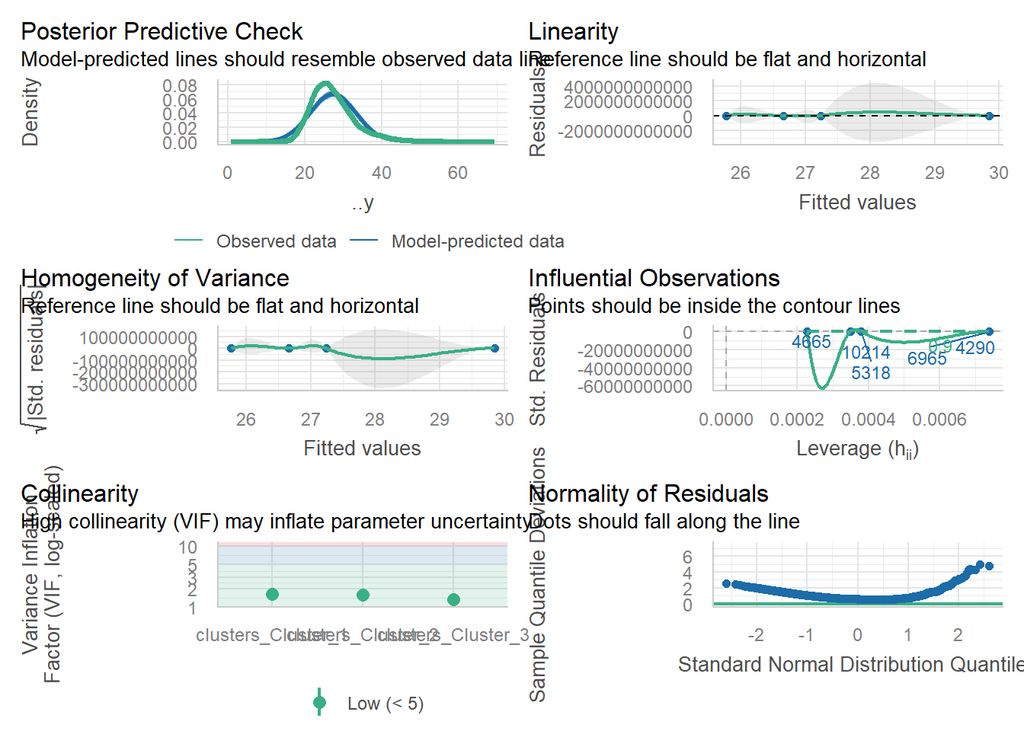

```r
bmi_fit_2 |>
  extract_fit_engine() |>
  check_model()
```

#### PCA based Linear regression VS Cluster based Linear regression

As it is presented in the above figure, the PCA-based regression model performs better than the cluster-based regression model. In the PCA model, the residual plots look more stable, the fitted values vary smoothly, and the assumptions of linear regression are better satisfied. Because PCA uses continuous components, it retains more information from the original variables and explains variation in BMI more effectively.

```r
pred_true_2 <- pred_true_2 |>
  rename(PM_BMI_SR = `PM_BMI_SR...1`)
```

```r
rsq(pred_true_2, truth = PM_BMI_SR,
         estimate = .pred)
```

```
## # A tibble: 1 × 3
##   .metric .estimator .estimate
##   <chr>   <chr>          <dbl>
## 1 rsq     standard      0.0592
```

### Q-5: Feature Importance Analysis

```r
coeff <- tidy(bmi_fit) %>%
  arrange(desc(abs(estimate))) %>%
  filter(abs(estimate) > 0.5)


kable(coeff)
```

| term | estimate | std.error | statistic | p.value |
| --- | --- | --- | --- | --- |
| (Intercept) | 27.404 | 0.054 | 510.5 | 0 |
| PC5 | 0.974 | 0.055 | 17.8 | 0 |
| PC1 | 0.723 | 0.044 | 16.6 | 0 |

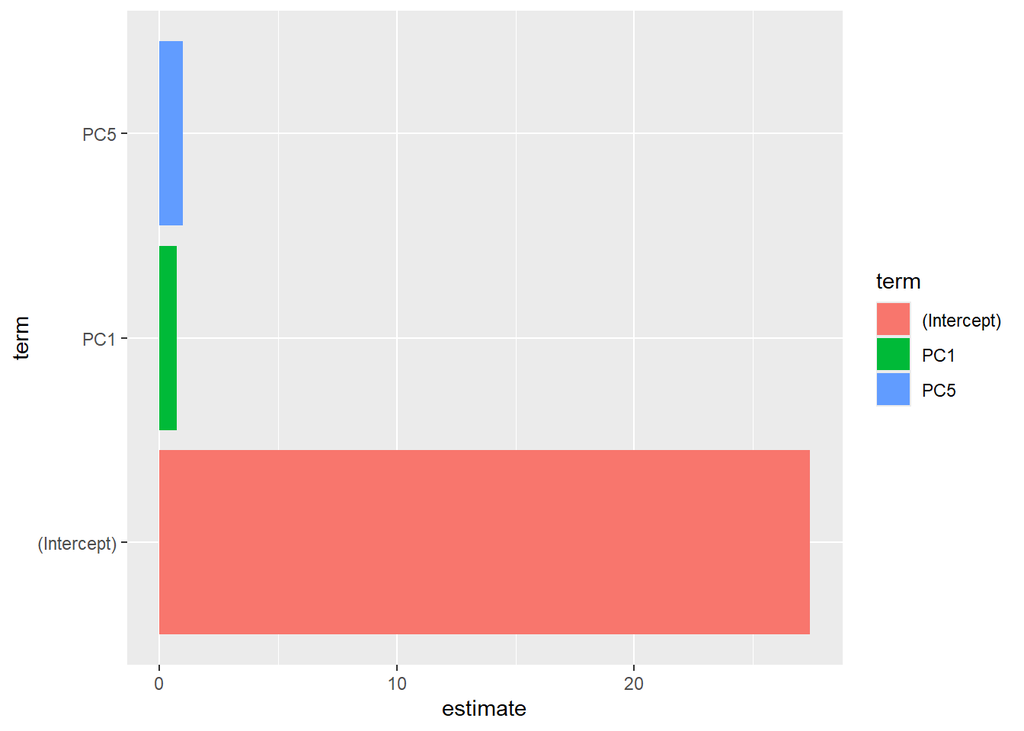

```r
# Plot of feature importance

ggplot(coeff, aes(x = term, y = estimate, fill = term)) + geom_col() + coord_flip()
```

**Interpretation:** Based on the feature importance analysis, PC5 and PC1 are the most influential components in predicting BMI.

*Note:* I have used copilot to understand the codes and explore the assignment.